# Financial Contributions to Presidential Campaigns by CA in 2016

The dataset was a collection of financial contributions to presidential campaigns by CA in 2016.

# Univariate Plots Section

```
## [1] 1304346      19
```

```
## 'data.frame':    1304346 obs. of  19 variables:
##  $ cmte_id          : Factor w/ 25 levels "C00458844","C00500587",..: 6 6 6 15 7 15 7 7 7 6 ...
##  $ cand_id          : Factor w/ 25 levels "P00003392","P20002671",..: 1 1 1 23 12 23 12 12 12 1 ...
##  $ cand_nm          : Factor w/ 25 levels "Bush, Jeb","Carson, Benjamin S.",..: 4 4 4 23 20 23 20 20 20 4 ...
##  $ contbr_nm        : Factor w/ 231294 levels "'CALL, BARBARA",..: 7753 31629 70312 175051 117924 176417 119377 119377 119411 92354 ...
##  $ contbr_city      : Factor w/ 2534 levels "","-4086","#NAME?",..: 1136 324 729 1183 323 1913 1810 1810 2402 1094 ...
##  $ contbr_st        : Factor w/ 1 level "CA": 1 1 1 1 1 1 1 1 1 1 ...
##  $ contbr_zip       : Factor w/ 143656 levels "","00000","000090272",..: 115155 71795 53864 126927 66455 139488 17327 17327 45924 58804 ...
##  $ contbr_employer  : Factor w/ 65600 levels "","''RETIRED''",..: 38794 38794 38794 27608 4491 27608 62116 62116 41406 38794 ...
##  $ contbr_occupation: Factor w/ 28622 levels "","''RETIRED''",..: 21476 21476 21476 12737 23942 12737 17980 17980 19679 21476 ...
##  $ contb_receipt_amt: num  50 200 5 48.3 40 ...
##  $ contb_receipt_dt : Factor w/ 732 levels "01-APR-15","01-APR-16",..: 596 446 27 486 85 564 108 132 85 446 ...
##  $ receipt_desc     : Factor w/ 74 levels "","* EARMARKED CONTRIBUTION: SEE BELOW REATTRIBUTION/REFUND PENDING",..: 1 1 1 1 1 1 1 1 1 1 ...
##  $ memo_cd          : Factor w/ 2 levels "","X": 2 2 2 2 1 2 1 1 1 2 ...
##  $ memo_text        : Factor w/ 428 levels "","$0.02 REFUNDED ON 10/21/2016",..: 126 126 126 1 90 1 90 90 90 126 ...
##  $ form_tp          : Factor w/ 3 levels "SA17A","SA18",..: 2 2 2 2 1 2 1 1 1 2 ...
##  $ file_num         : int  1091718 1091718 1091718 1146165 1077404 1146165 1077404 1077404 1077404 1091718 ...
##  $ tran_id          : Factor w/ 1300659 levels "A000771210424405B8CF",..: 466737 466019 463401 852428 1037145 890506 1038589 1040890 1036607 466057 ...
##  $ election_tp      : Factor w/ 5 levels "","G2016","O2016",..: 4 4 4 2 4 2 4 4 4 4 ...
##  $ X                : logi  NA NA NA NA NA NA ...
```

```
##       cmte_id            cand_id                            cand_nm
##  C00575795:688524   P00003392:688524   Clinton, Hillary Rodham  :688524
##  C00577130:407164   P60007168:407164   Sanders, Bernard         :407164
##  C00580100: 86258   P80001571: 86258   Trump, Donald J.         : 86258
##  C00574624: 57822   P60006111: 57822   Cruz, Rafael Edward 'Ted': 57822
##  C00573519: 27370   P60005915: 27370   Carson, Benjamin S.      : 27370
##  C00458844: 14095   P60006723: 14095   Rubio, Marco             : 14095
##  (Other)  : 23113   (Other)  : 23113   (Other)                  : 23113
##             contbr_nm              contbr_city     contbr_st
##  PETIT, MICHAEL  :    473   LOS ANGELES  :102710   CA:1304346
##  MITCHELL, MARCIA:    409   SAN FRANCISCO: 90937
##  SMITH, CHERYL   :    375   SAN DIEGO    : 46129
##  SAMATUA, DENISE :    373   OAKLAND      : 33235
##  CARROLL, TERI   :    352   SAN JOSE     : 30674
##  ADAM, MONIQUE   :    321   SACRAMENTO   : 23799
##  (Other)         :1302043   (Other)      :976862
##      contbr_zip           contbr_employer               contbr_occupation
##  92660    :    660   N/A          :185382   RETIRED              :260546
##  92037    :    565   RETIRED      :121569   NOT EMPLOYED         :115598
##  90049    :    495   SELF-EMPLOYED:120187   ATTORNEY             : 36640
##  92677    :    483   NONE         : 84297   INFORMATION REQUESTED: 30948
##  92067    :    474   NOT EMPLOYED : 50821   TEACHER              : 29104
##  911075001:    473   (Other)      :741411   (Other)              :831369
##  (Other)  :1301196   NA's         :   679   NA's                 :   141
##  contb_receipt_amt   contb_receipt_dt
##  Min.   :-10500.0   29-FEB-16:  11735
##  1st Qu.:    15.0   31-MAR-16:  11506
##  Median :    27.0   31-MAY-16:  10435
##  Mean   :   116.2   31-OCT-16:  10220
##  3rd Qu.:    88.0   06-NOV-16:  10199
##  Max.   : 10800.0   01-NOV-16:  10082
##                     (Other)  :1240169
##                                   receipt_desc     memo_cd
##                                         :1287456    :1104791
##  Refund                                 :  10413   X: 199555
##  REDESIGNATION FROM PRIMARY             :   1324
##  REDESIGNATION TO GENERAL               :   1324
##  REATTRIBUTION / REDESIGNATION REQUESTED:    569
##  REDESIGNATION TO CRUZ FOR SENATE       :    544
##  (Other)                                :   2716
```

[output cut: 9 more lines]

```
##  Min.   :1003942   A5602AD777C8C4632B5A:      4        :  1695
##  1st Qu.:1077916   ADB49CB248C174E298F0:      4   G2016:483991
##  Median :1099613   A26C35A6066754130B99:      3   O2016:   632
##  Mean   :1102796   A340DF85B7F884133A20:      3   P2016:818021
##  3rd Qu.:1133832   A4E50E2DD07E4475996F:      3   P2020:     7
##  Max.   :1146285   A7C22FA389E0348F98F0:      3
##                    (Other)             :1304326
##     X
##  Mode:logical
##  NA's:1304346
##
##
##
##
##
```

This dataset contained 19 variables and 130,4346 observations. And most variables are factor variables.

### Contribution Receipt Amount Distribution

From the summary, we could see that there were negative values for contribution receipt amount, which seemed pretty weird for me. So I removed the rows with negative contribution amount, and used the modified dataset for whole exploration.

And it was easy to figure out from the boxplot that for most times, people contributed for less than 100. And there were many outliers, some were pretty big, while some contribution amount were pretty small. I chose to keep these outliers, since they may be correlated with other variables. Maybe a specific candidate received most “outlier” contribution.

Since the contribution receipt amount distribution was highly skewed, so I transformed the long tail data to log scale. And the distribution was kind of like a normal distribution in log scale. And most contributions were around tens or hundreds.

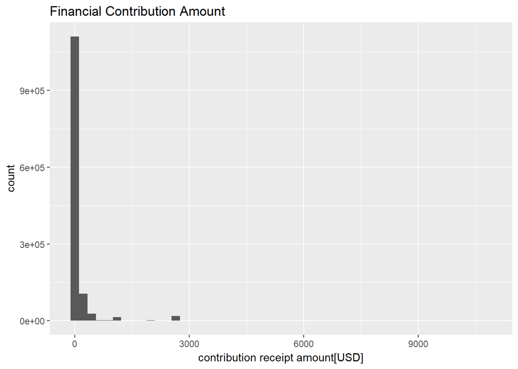

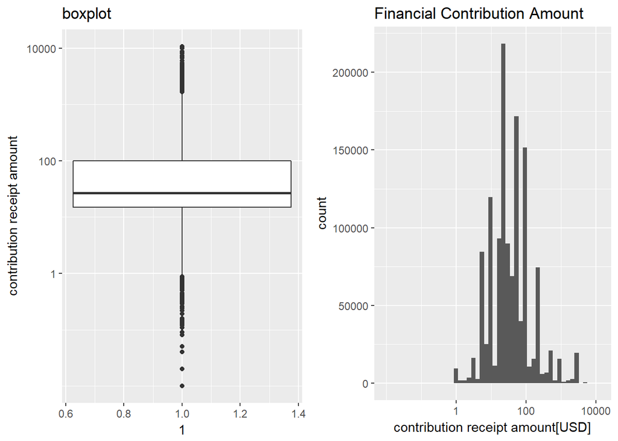

### Committee & Candidate

At first, I didn’t know the relationship between committees and candidates. But I found both variables had 25 unique values. So I combined the two variables to form a new one to check whether committee id and candidate id were related one by one. Actually, the answer was yes.

This bar chart shows that there were orders of magnitude difference of the financial support times. Four candidates, i.e., Clinton, Hillary Rodham and Sanders, Bernard and Trump, Donald J. and Cruz, Rafael Edward ‘Ted’, received financial support for most times. And Hillary Clinton was the top 1 candidate in receiving financial support ranked by count. Also, from the support times, we could tell that Democratic was more popular within CA.

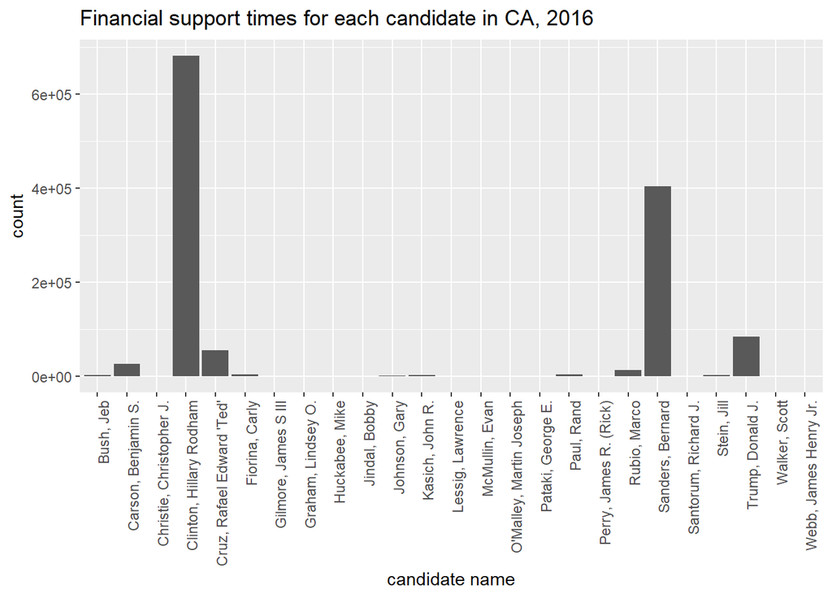

### Contributing Cities

Actually, there were 2517 unique cities contributed for the presidential campaign in CA in 2016. Here, I only showed the top 10 contributing cities ranked by count. We can easily figure out that Los Angeles, San Francisco and San Diego were top 3 contributing cities ranked by contribution times.

```
## [1] 2517
```

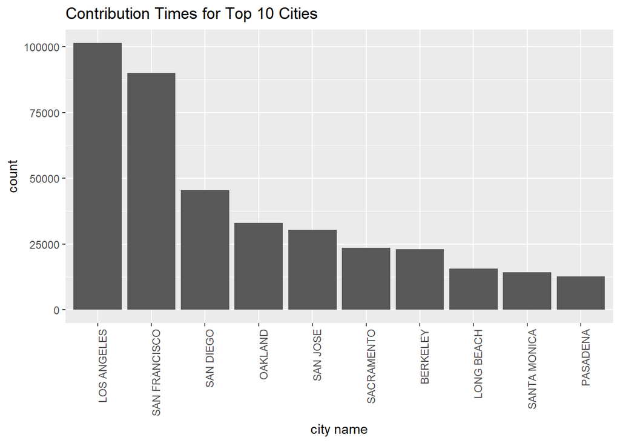

### Occupation

There were even more occupations in this dataset. Like city, I would only plot the top 10 occupations ranked by contribution times.

From the bar chart, I was quite curious why the retired and not employed people contributed most. Maybe because they were old and accumulated much money.

```
## [1] 28563
```

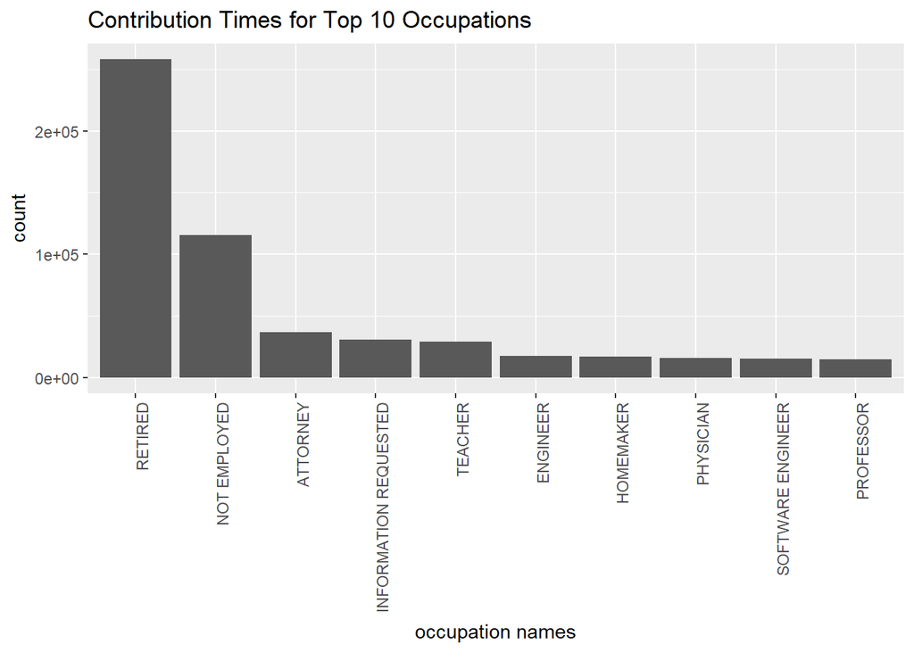

### Contribution Time Distribution

Since contribution time was considered as a factor variable, I needed to transform it to date format first. Here, I simply replaced the variable with Date format. Also, I created another column in this dataset, which only recorded the year and month of the contribution, which was used for later exploration and analysis.

When looking at the summary or plot, we could find that the earliest contribution started on 2013. Actually, we could see from the bar chart that most contributions were made in 2016. And there are two peaks in 2016, one in 201603 (during primary election), and the other in 201610 (one month before the general election).

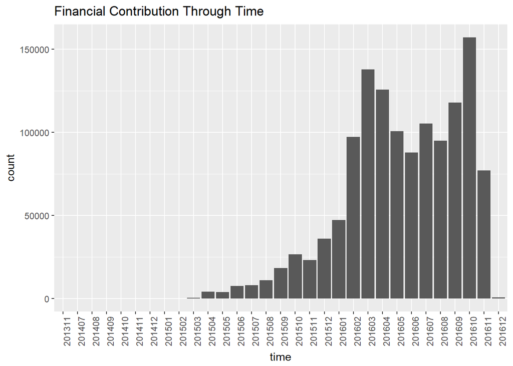

### Form Type

No longer which dataset to use, individual contributions accounted for a large proportion.

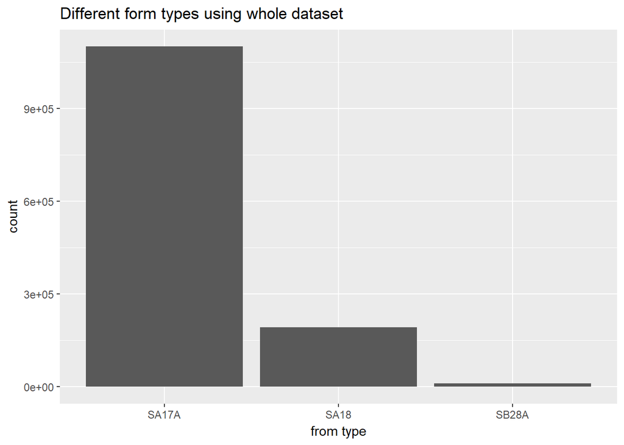

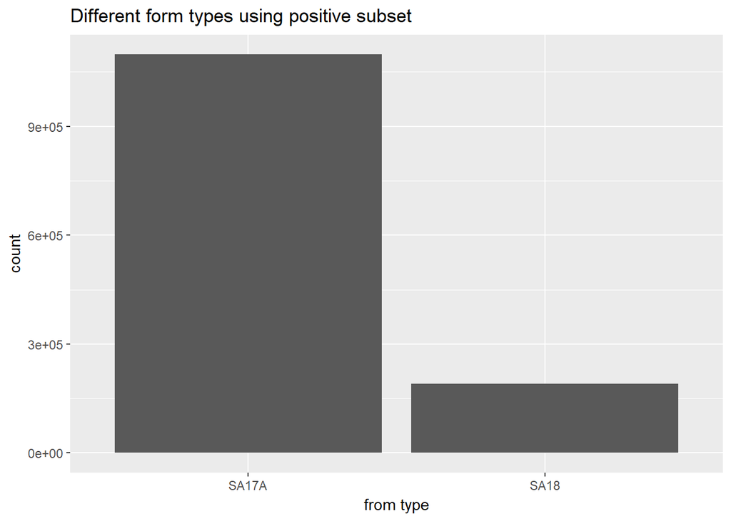

```
##   SA17A    SA18   SB28A
## 1097952  190028       0
```

### Election Type

Actullay, most contributions were made for primary election and general election. A few records have empty values for this variable and even 7 contributions were made for primary elections in 2020.

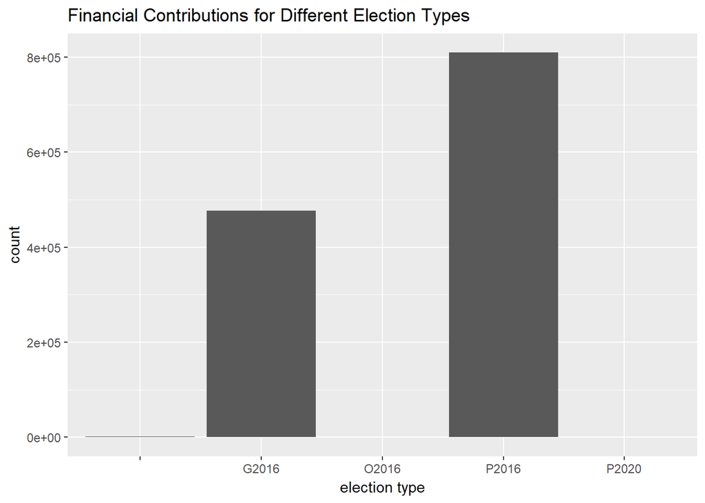

```
##         G2016  O2016  P2016  P2020
##   1544 476444    632 809353      7
```

# Univariate Analysis

### What is the structure of your dataset?

Most of the variables are factor variables, like contributing city, contributing name and etc. It was not a cross section dataset(snapshot taken at a given time). It recorded every financial contribution during the election process.

### Did you create any new variables from existing variables in the dataset?

There were a few changes I made to the original dataset.

- I changed the format of the contribution date and also creates another column (called `contb_receipt_dt_yr_mo`) representing the year and month of the contribution.
- I combined the committee id and candidate name to form a new column to check whether committees and candidates were correlated one by one.
- I created another two variables, i.e., top 10 cities and top 10 occupations ranked by contribution times since there were too many levels for cities and occupations.

### Of the features you investigated, were there any unusual distributions? Did you perform any operations on the data to tidy, adjust, or change the form of the data? If so, why did you do this?

1. There were some records with negative contribution receipt amount in the dataset(called `original_financial`). So I excluded all negative values in my dataset and I used modified dataset(called `financial`) for my exploration.
2. And retired man contributed most times of all occupations, which really surprised me.

# Bivariate Plots Section

When doing the univariate visualizations and analysis, the y axis for bar charts or histograms was count, or contribution times. And since each contribution receipt amount was different, so it was a good idea to explore how total contribution amount varied with some categorical variables. To achieve this, aggregation was needed.

### Candidate & Contribution Receipt Amount

From the first plot, we could see that there was orders of magnitude difference for each candidate. So I changed to log10 scale for better understanding. Of all candidates, Clinton, Hillary Rodham received the most total contribution amount. And for other candidates, I could always find another candidate with similar total contribution amount received.

From the statistics, we could also see that the mean value was much larger than the median and the third quantile, underlying that the outliers pushed the mean value to the right. And the max value, which Clinton received, was hundred times larger than the median value.

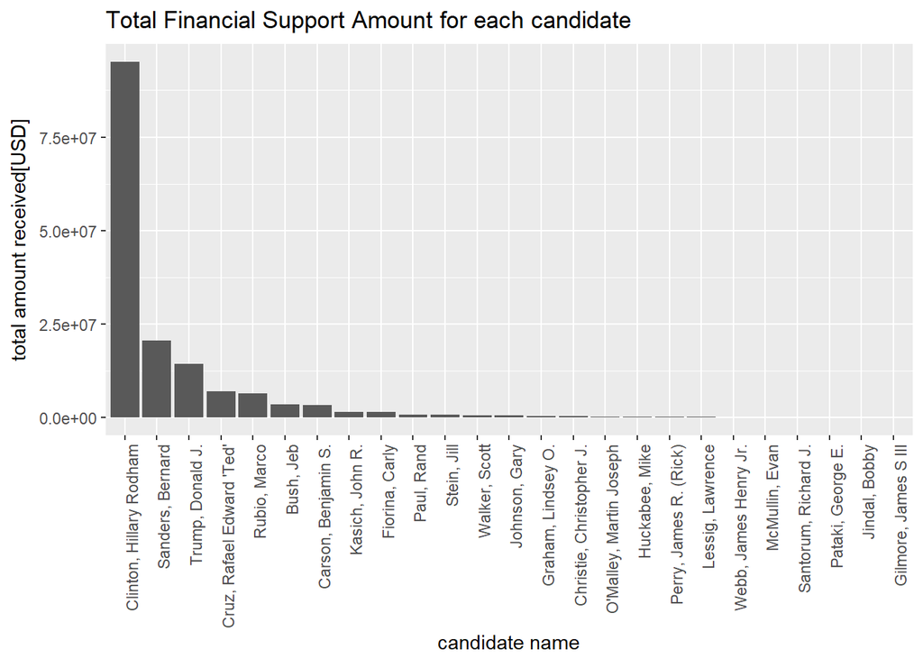

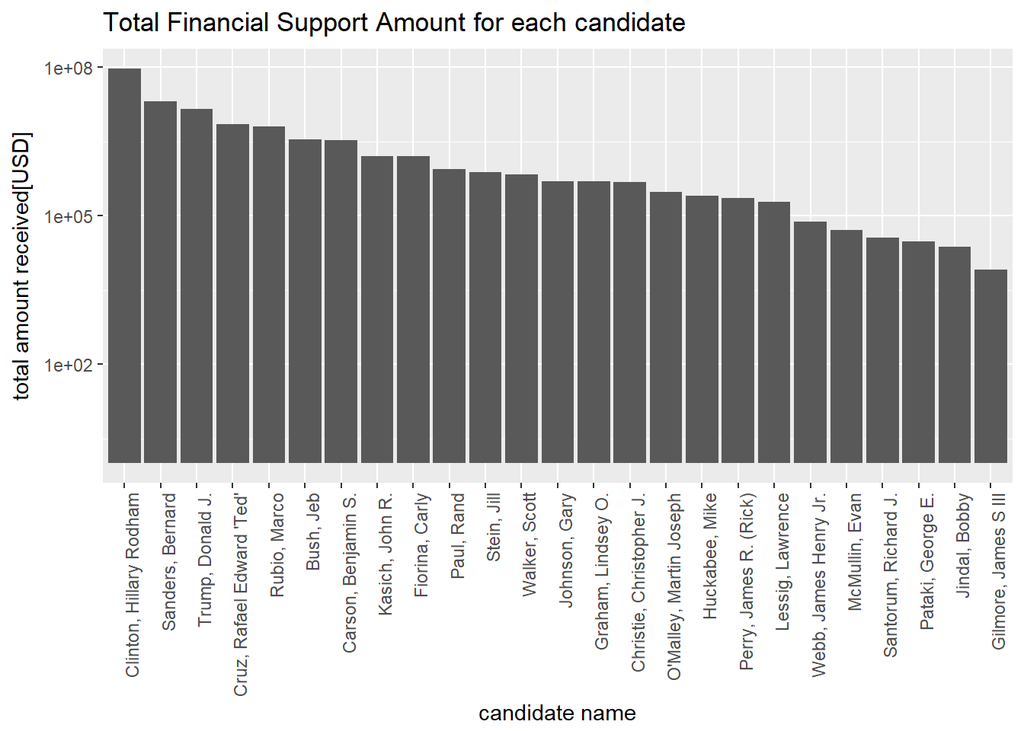

```
##     Min.  1st Qu.   Median     Mean  3rd Qu.     Max.
##     8100   188844   496023  6344531  3318441 95187058
```

### City & Contribution Receipt Amount

Since there were more than 2500 cities in this dataset, so I would still explore top 10 cities, but this time with total contribution amount. While considering the total financial support amount, rather than contribution times, San Francisco and Los Angeles were still top 2 cities, while the other cities’ difference got less.

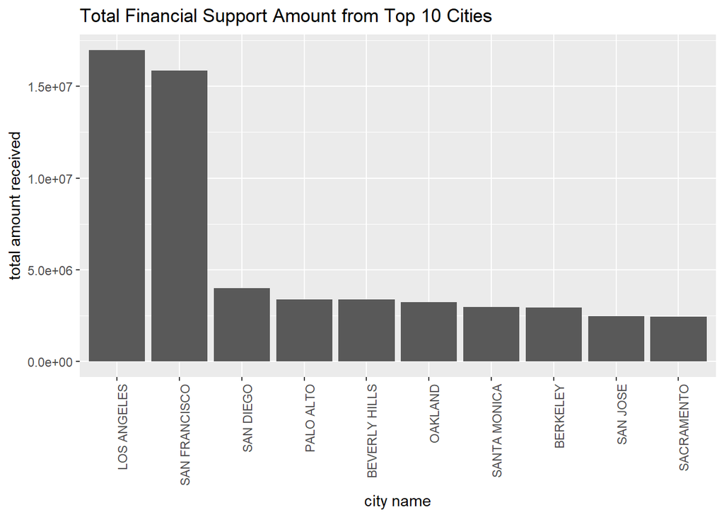

```
##     Min.  1st Qu.   Median     Mean  3rd Qu.     Max.
##        2      120      954    63017    11957 16986730
```

```
##     Min.  1st Qu.   Median     Mean  3rd Qu.     Max.
##  2435487  2936965  3303845  5762012  3843315 16986730
```

### top 10 contribution city & candidate

Here I only cared about three candidates, Clinton, Hillary Rodham, Sanders, Bernard and Trump, Donald J. While Clinton and Sanders had very similar trend in each city, Trump differed. Contributions from San Diego accounted a large propotion for Trump, while was not true for Clinton and Sander. **So it was natural to think that different cities had different preferences in candidate and party.**

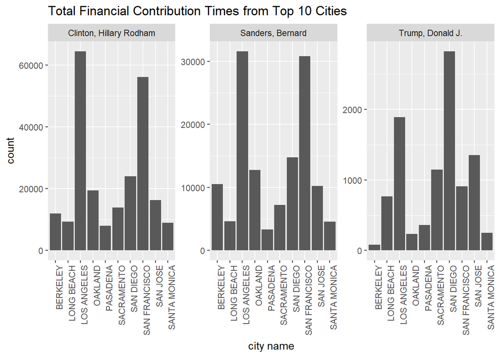

### Contribution Time & Contribution Receipt Amount

Obviously, the distribution was quite different from the one gotten from univariate plotting. Contributions in 2015 seemed to accounted for a larger proportion. Maybe it was due to large amount per contribution in 2015. Also, 201607-201610 were the most intense periods.

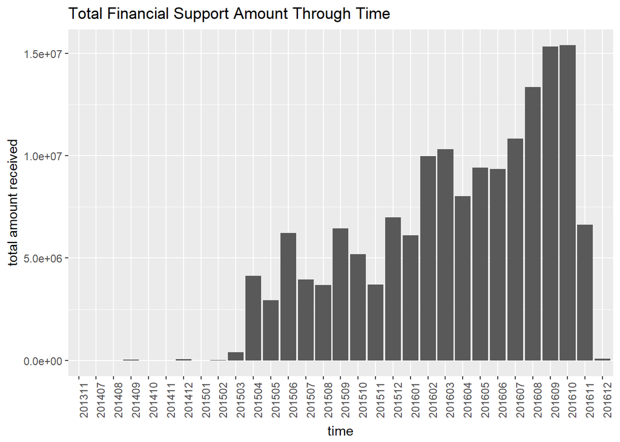

### Candidate & Election Type

We can see that during primary election, more candidates were financially supported, which was consistent with the election rule. Even Sanders, Bernard received much contribution during primary election process, but he received 0 for general election.

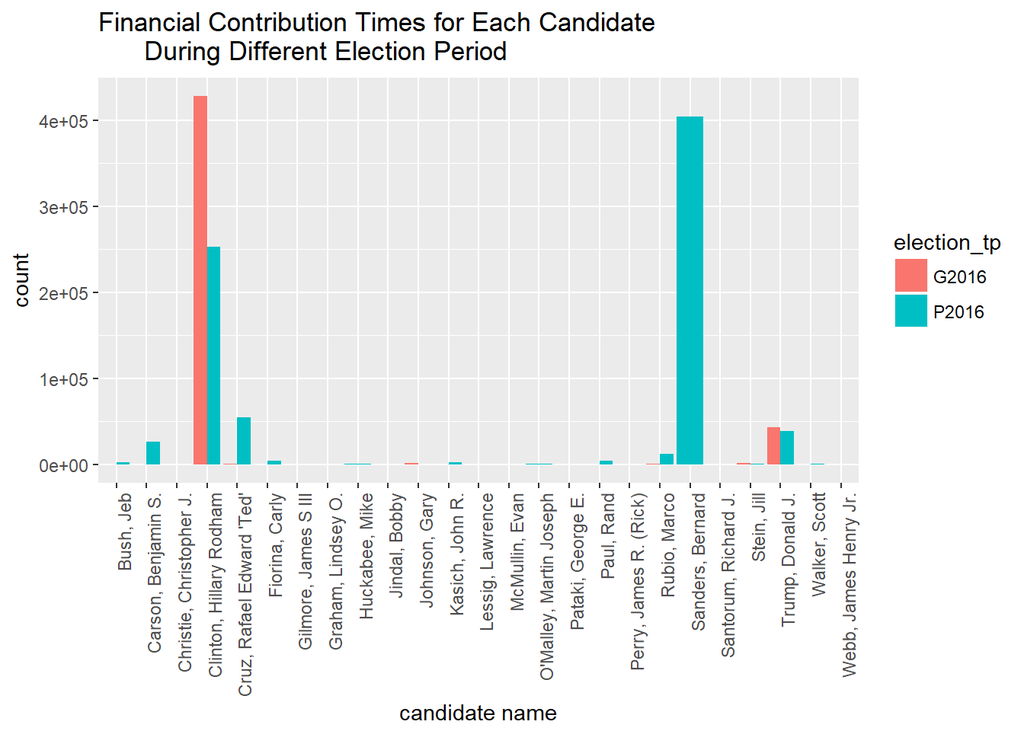

# Bivariate Analysis

### Talk about some of the relationships you observed in this part of the investigation. How did the feature(s) of interest vary with other features in the dataset?

- When doing univariate analysis, I explored the count(contribution times) of some variables, like contribution city, candidate name. And when doing bivariate analysis, I primarily changed the frequency(contribution times) to contribution receipt amount. And the most conclusions in univariate analysis still worked for bivariate analysis, but the distribution changed.

### Did you observe any interesting relationships between the other features (not the main feature(s) of interest)?

- Candidates got different “treatment” in different cities which may be due to cities’ party perference. For example, contributions from San Diego accounted a large propotion for Trump, while was not true for Clinton and Sander.
- The election rule affected the actual data. Some candidates didn’t stand out  
  from the primary election, then they couldn’t compete in general election. Thus only a few candidates receive financial support. Even though Sanders received more contribution than Trump, Clinton won Sanders and she was supported at last.

### What was the strongest relationship you found?

Since there were only one numerical variable(i.e., contribution receipt amount), so scatterplot was not suitable here. Thus no linear or non-linear relationship were found in this dataset. But We could still see that the contribution receipt amount varied as the candidate or contributing city changed.

# Multivariate Plots Section

### City & Candidate & Contribution Receipt Amount

Here I still only cared about three candidates, Clinton, Hillary Rodham, Sanders, Bernard and Trump, Donald J. Also, I only explored the top 10 contributing cities ranked by total contribution amount.

I was pretty surprised to find from the boxplot that for almost every top 10 city, the median and third quantile contribution amount for Trump was larger than Clinton and Sanders, which was not consistent with the fact that Clinton and Sanders received much more contribution than Trump. I guessed that maybe that was due to the outliers. The contribution with pretty large amount really counted when calculating total contribution amount.

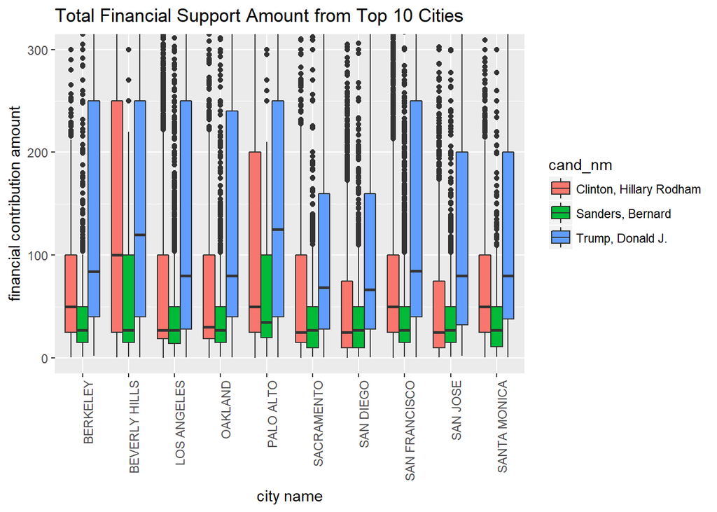

### Election Type & Contribution Amount & Candidate

To better visualization, I transformed y axis to log scale. We could see that 9 wide blue bars, underlying that they didn’t participate in the generation election. I was also surprised to find that McMullin, Evan only received contribution in general election process. While I searched online and found that he didn’t launch an independent presidential bid util August, 2016.

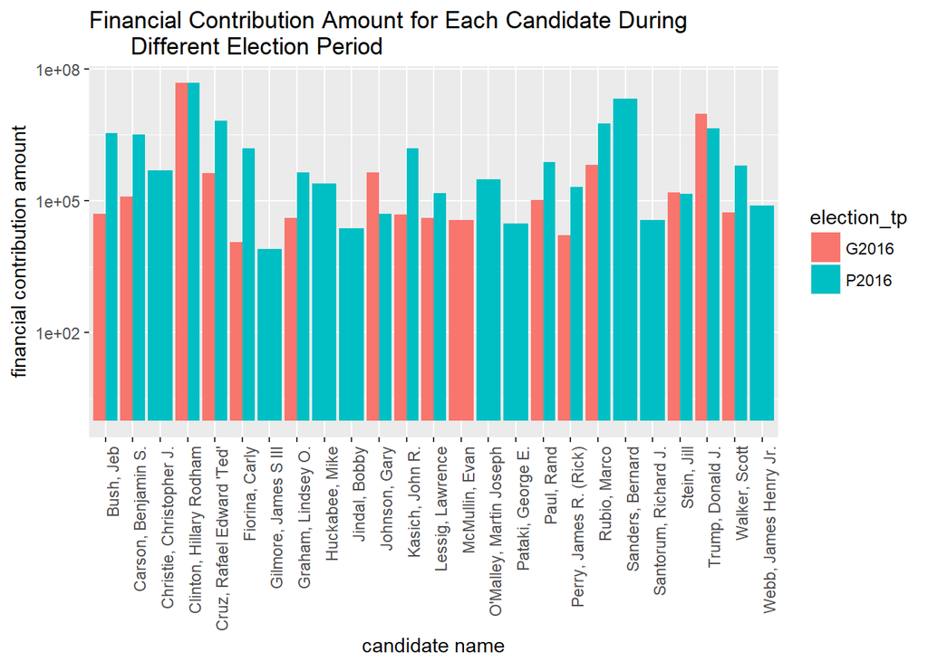

### Contribution Amount & Candidate & Time

Since the dataset was not a cross-section one, it was a good idea to look at how the support trend varied with time for each candidate.

Trend for each candidate varied a lot. Clinton kept “smooth” contribution through the process, while some candidates went up and down, like Cruz, Rafael Edward ‘Ted’.

There were candidates receiving support from a quite early time, like Paul, Rand. While some candidates received financial support from very late period, like McMullin, Evan, which I discussed above. I thought this plot contained much information. It was better to explore if I combined the data with the events in reality.

Since exploring how contribution amount varied for each candidate was too hard to intepret. So I drew another one containing only top 3 candidates. These candidates showed very different trends. Contribution to Clinton kept smooth in some sense, while contributions to Sanders declined sharply in later process, and contributions to Trump went upwards during April, 2016.

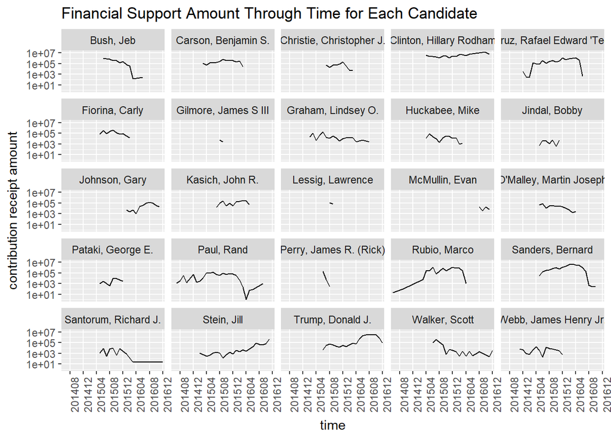

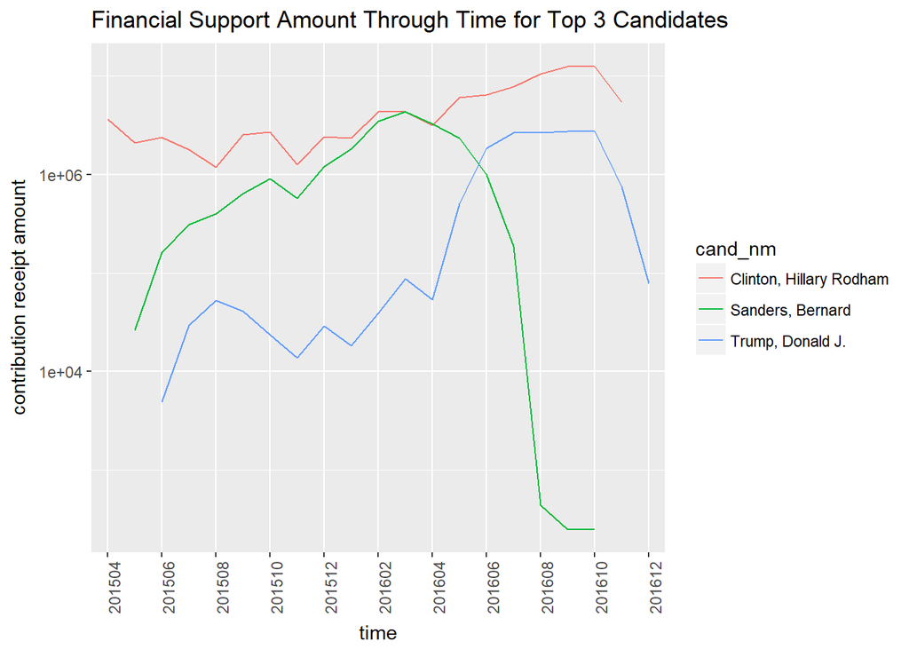

### Contribution Amount & City & Time

The contribution trend for each city seemed quite similar. First increase, then keeping smooth, and at last dropped.

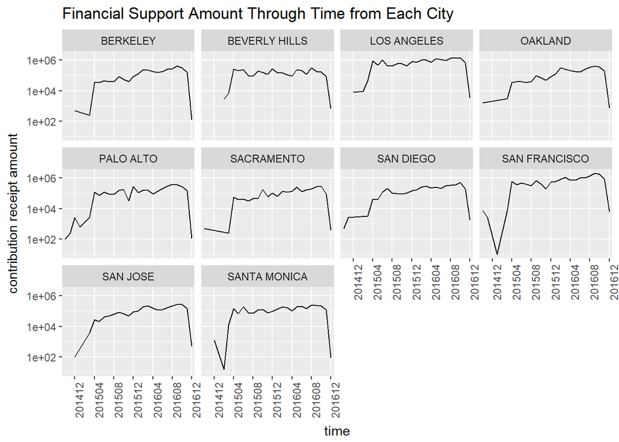

### Map distribution

To plot on the map, first, I grouped the contribution amount by zipcode, then, I combined aggregated data with `zipcode`, which was provided by package `zipcode`, to get latitude and longitude. So in this plot, the size of circles represented the total contribution amount during 2016 presidential campaign.

Actually, this plot was not as explicit as the previous ones, because it was a little hard to distinguish between each city. And this plot had problem on overplotting and needed further improvement. But the advantage of this map was that it showed all cities, not just top 10 cities any more.

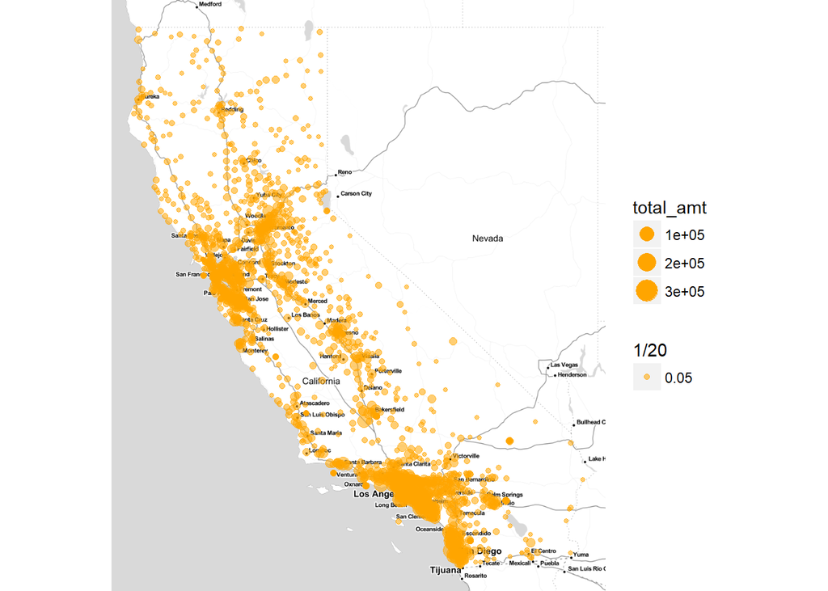

### General Election Preference for Clinton or Trump

Here, I only cared about Hillary Clinton and Donald Trump. And I would only use the contribution data for general election.

While ratio 1 meant that the city only contributed to Clinton, and ratio 0 meant the city only contributed to Trump. And We could see from this plot that different cities had different preferences, which may need further exploration in the future.

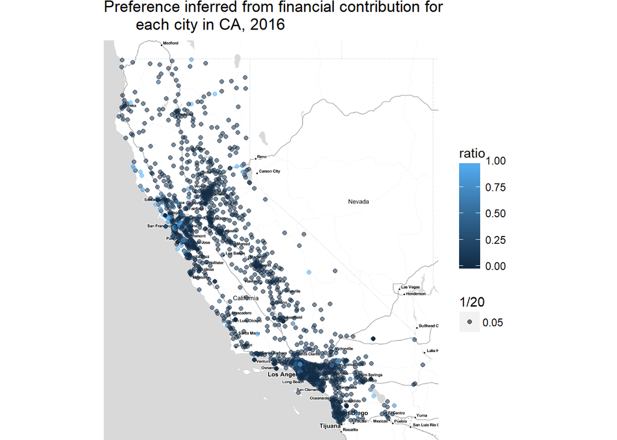

### General Election Prediction

Here, I simply used the financial contribution data to predict the general election result. And we may get the result that Hillary Clinton would win CA, but the actual ratio(61.73%) was much lower than predicted one(80.48%).

It may be due to bias. Bbecause only rich people would contribute to the candidates and normal people were not considred in this prediction.

```
## # A tibble: 16 x 4
##                      cand_nm   total_amt      n    amt_ratio
##                       <fctr>       <dbl>  <int>        <dbl>
##  1                 Bush, Jeb    50406.40     31 0.0008473300
##  2       Carson, Benjamin S.   125898.20    185 0.0021163448
##  3   Clinton, Hillary Rodham 47877236.64 428362 0.8048148480
##  4 Cruz, Rafael Edward 'Ted'   427059.07    752 0.0071788496
##  5            Fiorina, Carly    11350.00      8 0.0001907931
##  6        Graham, Lindsey O.    40800.00     18 0.0006858467
##  7             Johnson, Gary   446235.65   1674 0.0075012073
##  8           Kasich, John R.    48652.00     47 0.0008178386
##  9          Lessig, Lawrence    40811.98     18 0.0006860481
## 10            McMullin, Evan    35935.50    153 0.0006040746
## 11                Paul, Rand   102293.73     77 0.0017195544
## 12    Perry, James R. (Rick)    16200.00      6 0.0002723215
## 13              Rubio, Marco   644903.20    407 0.0108408026
## 14               Stein, Jill   153397.22   1397 0.0025786025
## 15          Trump, Donald J.  9412381.04  43283 0.1582218304
## 16             Walker, Scott    54950.00     26 0.0009237078
```

# Multivariate Analysis

### Talk about some of the relationships you observed in this part of the investigation. Were there features that strengthened each other in terms of looking at your feature(s) of interest?

- As discussed from the bivariate analysis, I learned that different cities had different preferences. And in this part, I not only explored the how contribution amount varied among different cities. I also drew cities’ preference on the map and the preference was calculated using the financial contribution amount ratio and only Clinton and Trump was considered during the calculation process.
- The contribution trend for each city seemed quite similar.
- The contribution trend for each candidated was quite different. Some candidates kept smooth, whild some kept up and down. And the starting time and lasting time also varied a lot.

### Were there any interesting or surprising interactions between features?

- I think the result was quite surprising when combining candidate and time. In this way, much more information was added in.
- Also, I was pretty surprised to find that for almost every top 10 city, the median and third quantile contribution amount for Trump was larger than Clinton and Sanders, which was not consistent with the fact that Clinton and Sanders received much more contribution than Trump. I guessed that maybe that was due to the outliers. The contribution with pretty large amount really counted when calculating total contribution amount.

### OPTIONAL: Did you create any models with your dataset? Discuss the strengths and limitations of your model.

I used a very simple model to predict who would won CA in general election. And the result was consistent with reality, but the ratio was pretty much biased.

I thought the this method may tell who will win one specific state when the contribution data for two main competitors had a big difference, like this dataset. But when the contribution amount was quite similar, this method would fail with pretty large probability.

And I thought the bias came from the non-respondents bias. Since only rich peole would contribute and normal people were not considered in this prediction model.

# Final Plots and Summary

### Plot One

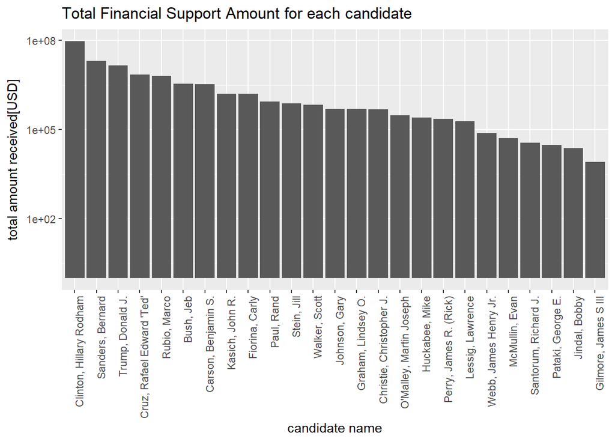

### Description One

This plot shows the total contribution amount that each candidate received in the presidential election campaign. From this plot, we could easily figure out the most popular candidate in CA, 2016. And when we looked further into this plot, we could also figure out the democratic party were more popular than other parties.

### Plot Two

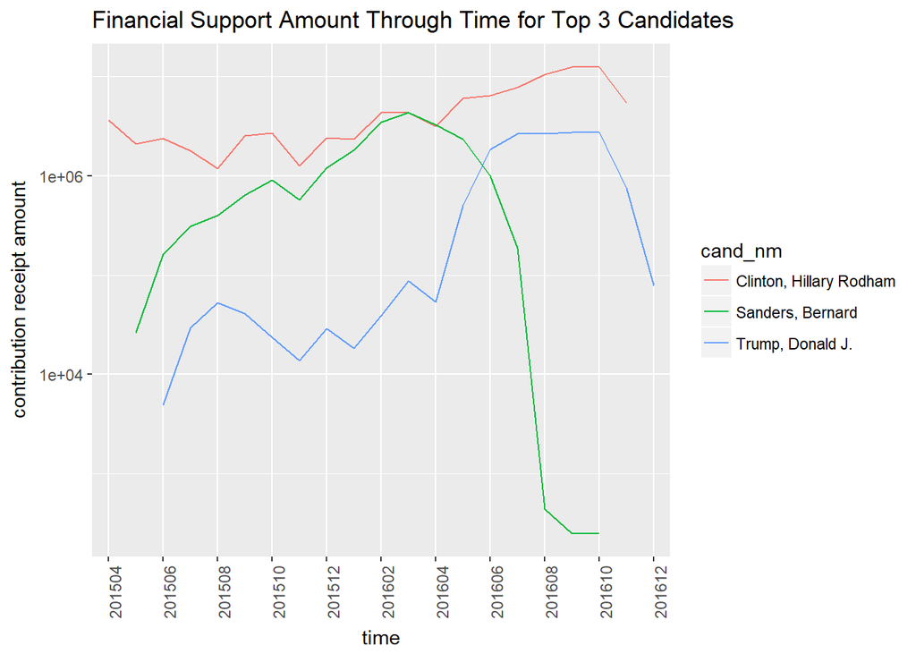

### Description Two

This plot showed the how contribution amount varied with time for top 3 popular candidates. We could see the ups and downs for these candidates. Clinton kept similar contributions all the time. Contributions to Sanders declined sharply in later process, and contributions to Trump went upwards after April, 2016.

### Plot Three

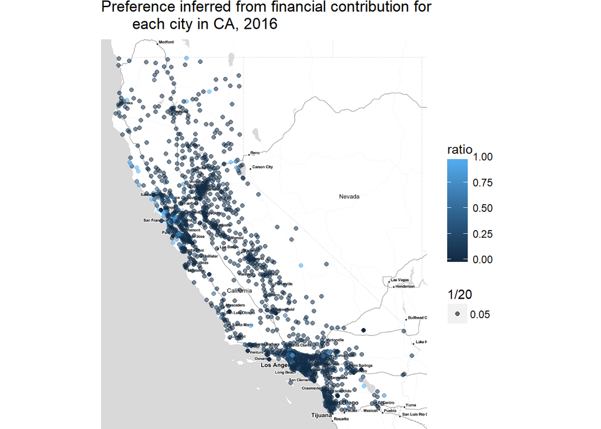

### Description Three

This plot showed different cities had different preferences. While ratio 1 meant that the city only contributed to Clinton, and ratio 0 meant the city only contributed to Trump.

# Reflection

In this dataset, I’m interested to find how financial contribution for each candidate in presidential campign in CA varied and want to figure out who was the most popular candidate in CA, 2016. I’m also interested in using financial support data to predict the proportion of votes in general election in CA,2016. I thought I’ve basically finished my goal.

For univariate analysis, I mainly explored the frequency or contribution times for one categorical variables. And for bivariate analysis, I changed the frequency to actual total contribution amount. And for multivariate analysis, I plotted how the contribution amount changed through time for a categorical variable. Also, I combined the data with geographic information.

There are times that I got confused on frequency and total amount. So, it was a good idea to jump out of the analysis and consider the whole analysis at times. Also, during the exploration process, I’ve dropped into a trap that I used very few ways to analyze. And the reviewer has pointed it out and suggested that I could use colors instead of `facet_wrap` and use boxplots as well.

What I found interesting or surprising was as follows:

- Different cities had different preferences over candidates.
- Each candidate went different ups and downs through the election process.
- I still couldn’t understand why retired or not employed people contributed most.
- The median and mean value for Trump was higher than Clinton.

Before the analysis, I knew little about the election process and was confused by primary election and general election. But going through the exploration process, I gained some knowledge about American election.

For future analysis, to better intepret the data, it would be very important to combine the data with reality. And it’s one drawback in my current analysis. Also, I should put more effort later to improve the visualization and interpretation of maps.